# Structural Topic Modelling

PS239T

Fall 2016

This unit gives a brief overview of the stm (structural topic model) package. Please read the vignette for more detail.

Structural topic model is a way to estimate a topic model that includes document-level meta-data. One can then see how topical prevalence changes according to that meta-data.

### Setup Environment and Load Data

First let’s load our required packages.

```r
setwd("~/Desktop/PS239T/12_text-analysis") # YOUR DIRECTORY HERE
rm(list=ls())
library(stm)
library(plyr)
```

## 0. Load Ddata

The data we’ll be using for this unit consists of all articles about women published in the New York Times and Washington Post, 1980-2014.

**NOTE** I downloaded these articles from Lexis Nexis and then used [this script](http://nealcaren.web.unc.edu/cleaning-up-lexisnexis-files/) to parse it into a csv

```r
# Load Data
women <- read.csv('Data/women-full.csv')
names(women)
```

```
##  [1] "BYLINE"              "TEXT.NO.NOUN"        "PUBLICATION"
##  [4] "TITLE"               "COUNTRY"             "COUNTRY_FINAL"
##  [7] "YEAR"                "UID"                 "COUNTRY_NR"
## [10] "entities"            "LENGTH"              "COUNTRY_TOP_PERCENT"
## [13] "COUNTRY_CODE"        "TEXT"                "DATE"
## [16] "COUNTRY_MAJOR"       "TYPE"                "REGION"
## [19] "SUBJECT"
```

Notice that we have the text of the articles, along with some metadata.

## 1. Preprocessing

STM has its own unique preprocessing functions. We’re first going to create our own custom stop words (words to remove), containing country names.

```r
# Country custom stopwords
countries <- unique(women$COUNTRY_FINAL)
stopwords.country <- c(as.character(countries), "saudi", "german", "ese", "ian")
stopwords.country <- tolower(stopwords.country)
```

Now we’ll follow STM’s preprocessing procedure. Notice that we’re going to use the `TEXT.NO.NOUN` column, which contains all the text of the articles without proper nouns (which I removed earlier)

```r
# Pre-process
temp<-textProcessor(documents=women$TEXT.NO.NOUN, metadata=women, customstopwords=stopwords.country)
```

```
## Building corpus...
## Converting to Lower Case...
## Removing stopwords...
## Remove Custom Stopwords...
## Removing numbers...
## Removing punctuation...
## Stemming...
## Creating Output...
```

```r
meta<-temp$meta
vocab<-temp$vocab
docs<-temp$documents
out <- prepDocuments(docs, vocab, meta, lower.thresh=10)
```

```
## Removing 29915 of 37600 terms (66707 of 1076537 tokens) due to frequency
## Your corpus now has 4531 documents, 7685 terms and 1009830 tokens.
```

```r
docs<-out$documents
vocab<-out$vocab
meta <-out$meta
```

## 2. Estimate Model

We’re now going to estimate a topic model with 15 topics by regressing topical prevalence on region, year, and publication covariates. I’ve included the code below but it takes a **long** time to finish. The second line of code loads the already-estimated model, which I’ve saved as an .RData object.

```r
# Uncomment to run -- it will take awhile! Take out the `max.em.its` argument to run to convergence.
# model <- stm(docs,vocab, 15, prevalence=~REGION+s(YEAR)+PUBLICATION, data=meta, seed = 15, max.em.its = 50)

# load the already-estimated model.
load("Data/stm.RData")
```

## 3. Explore the model

Let’s see what our model came up with!

- `topicQuality` plots topics on their coherence and exclusivity scores.
- `labelTopics` gives the top words for each topic.
- `findThoughts` gives the top documents for each topic (the documents with the highest proportion of each topic)

I then use those to apply hand labels to each topic.

```
##  [1] -55.84024 -58.51133 -77.85125 -58.18039 -58.89740 -38.91734 -54.85281
##  [8] -64.40270 -41.25055 -52.43875 -49.88050 -29.84326 -51.28140 -66.65177
## [15] -60.53721
##  [1] 9.586821 9.512017 9.490585 9.347528 8.910393 9.516634 9.793183
##  [8] 9.397022 9.849227 9.714044 9.583004 9.713489 9.562353 9.227442
## [15] 9.484088
```

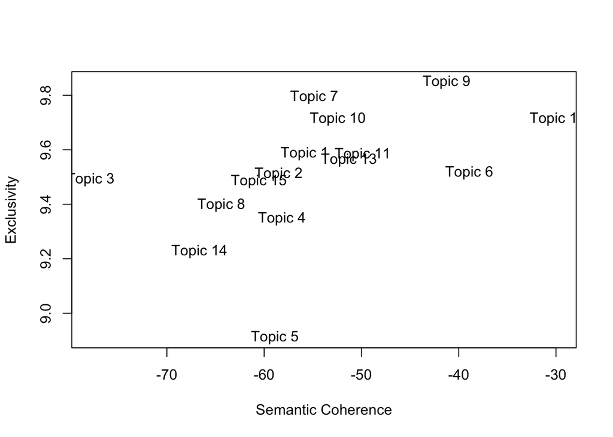

```r
# Topic Quality plot
topicQuality(model=model, documents=docs)
```

```r
# Top Words
labelTopics(model)
```

```
## Topic 1 Top Words:
##       Highest Prob: said, work, compani, year, percent, job, busi
##       FREX: compani, bank, industri, factori, employ, market, employe
##       Lift: entrepreneurship, lender, payrol, workingag, boardroom, merger, microfin
##       Score: acquitt, antiretrovir, azt, biopsi, chiffon, coutur, epidemiologist
## Topic 2 Top Words:
##       Highest Prob: team, women, game, play, world, said, olymp
##       FREX: game, olymp, sport, player, soccer, athlet, coach
##       Lift: gymnast, athlet, championship, coach, footbal, medal, medalist
##       Score: antiretrovir, biopsi, chiffon, coutur, epidemiologist, goali, goalkeep
## Topic 3 Top Words:
##       Highest Prob: cancer, health, women, doctor, said, hospit, aid
##       FREX: cancer, infect, patient, clinic, virus, hospit, doctor
##       Lift: pregnancyrel, antiretrovir, hiv, infect, mastectomi, nevirapin, node
##       Score: acquitt, antiretrovir, azt, biopsi, coutur, epidemiologist, goalkeep
## Topic 4 Top Words:
##       Highest Prob: black, dress, one, cloth, wear, design, street
##       FREX: restaur, jacket, shirt, color, skirt, blue, worn
##       Lift: champagn, roast, beig, flannel, flap, laci, pickl
##       Score: acquitt, antiretrovir, azt, biopsi, chiffon, coutur, epidemiologist
## Topic 5 Top Words:
##       Highest Prob: film, book, show, art, work, stori, life
##       FREX: film, artist, novel, art, museum, theater, movi
##       Lift: asterisk, autobiograph, avantgard, catalog, contriv, corset, costar
##       Score: acquitt, antiretrovir, biopsi, chiffon, coutur, goalkeep, haut
## Topic 6 Top Words:
##       Highest Prob: women, said, will, right, confer, organ, group
##       FREX: confer, deleg, forum, organ, meet, intern, secretari
##       Lift: zionism, deleg, nongovernment, bipartisan, walkout, confer, forum
##       Score: acquitt, antiretrovir, azt, biopsi, chiffon, coutur, epidemiologist
## Topic 7 Top Words:
##       Highest Prob: said, polic, rape, case, report, sexual, violenc
##       FREX: rape, crime, victim, sentenc, crimin, polic, gang
##       Lift: prosecutor, rapist, accomplic, acquit, acquitt, anticorrupt, constabl
##       Score: acquitt, antiretrovir, azt, chiffon, epidemiologist, goalkeep, immunodefici
## Topic 8 Top Words:
##       Highest Prob: said, war, militari, kill, attack, soldier, women
##       FREX: soldier, troop, bomb, armi, militari, combat, command
##       Lift: artilleri, checkpoint, col, artsentertain, barrack, battalion, brig
##       Score: acquitt, antiretrovir, chiffon, coutur, epidemiologist, goali, goalkeep
```

[output cut: 20 more lines]

```
## Topic 13 Top Words:
##       Highest Prob: famili, girl, women, husband, said, children, villag
##       FREX: villag, marriag, famili, rural, bride, marri, girl
##       Lift: villag, fatherlaw, matchmak, bride, dowri, nomad, elop
##       Score: acquitt, antiretrovir, azt, biopsi, chiffon, coutur, epidemiologist
## Topic 14 Top Words:
##       Highest Prob: said, islam, religi, right, church, ban, law
##       FREX: islam, religi, religion, secular, veil, circumcis, fundamentalist
##       Lift: hijab, secular, ultraconserv, burqa, clergi, fatwa, imam
##       Score: acquitt, chiffon, coutur, epidemiologist, goalkeep, haut, immunodefici
## Topic 15 Top Words:
##       Highest Prob: abort, studi, women, said, research, use, percent
##       FREX: abort, pill, contracept, fertil, implant, hormon, research
##       Lift: estrogen, menopaus, ovul, densiti, hormon, intrauterin, menstrual
##       Score: acquitt, antiretrovir, azt, biopsi, chiffon, coutur, epidemiologist
```

```r
# Example Docs
findThoughts(model,texts=meta$TITLE,n=3,topics=1:15)
```

```
##
##  Topic 1:
##       COMPANY NEWS; LIZ CLAIBORNE AGREES TO BUY DUTCH CLOTHING COMPANY
##      Competing to Supply Retail Giants; Report Finds Long Hours, Low Wages for Females
##      INTERNATIONAL BRIEFS; Bauer of Germany Joins Bidding for Unit
##  Topic 2:
##       Kramer, Sablikova Win World Titles
##      Bridge: U.S. Women Fall to Second In World Team Title Event
##      Bridge; Brazil holds its lead in the Bermuda Bowl; the Netherlands wins the women's team contest.
##  Topic 3:
##       Mothers at Risk
##      World Briefing Africa: Mozambique: 139,000 H.I.V. Babies In 6 Months
##      Safe Births in Africa
##  Topic 4:
##       The Chic of Africa; Swahili Skirts
##      CHOICE TABLES; For Japan's Female Chefs, More Than Home Fires
##      In St.-Denis, an Oasis for Women
##  Topic 5:
##       Film: Brazilian 'Vera'
##      Runway in Review
##      Women's Status in Vietnam In Documentary Form
##  Topic 6:
##       'CHAOTIC' CONDITIONS FEARED AT U.N.'S PARLEY ON WOMEN
##      Corrections
##      U.N. Bars Ethnic Tibetan's Talk, Stirring Protests
##  Topic 7:
##       Third Suspect Arrested in the Mumbai Gang Rape
##      India Rape Trial Starts With Renewed Ban on Media Coverage
##      Charges Carrying Death Penalty Filed in Mumbai Gang Rapes
##  Topic 8:
##       2 BRITONS KIDNAPPED IN BEIRUT
##      Assailants Kill 4 Iraqi Women Working for U.S.; Gunmen Follow Van Carrying Laundry Employees
##      17 Iraqis Killed in Insurgent Attacks; Police and Civilians Are Hit Hardest as American Forces Pull Back to Bases
##  Topic 9:
##       No Comment Necessary: Women 'Created Differently'
##      Equal Status for Wives Urged By South African Legal Panel
##      European Union Court Ruling Limits Job Preference for Women
##  Topic 10:
##       World Briefing Americas: Brazil: A Woman On The Ticket
##      HEADLINERS; Unmade in Japan
##      2 New Parties Gain Parliament in Iceland
##  Topic 11:
##       Betty Throne-Holst, Foundation Aide, 61
##      Bertha Levin, Hadassah Pioneer, 98
##      Stanford Scholar Dies In a Fall in Philippines
##  Topic 12:
##       From One Maternity Ward, a Growing World
##      Common Moments That Still Exist
##      The Gender Gap in Travel: Myths and Revelations
##  Topic 13:
##       As Families Emigrate, Hong Kong's Elderly and Afflicted Are Left Stranded
##      Though Illegal, Child Marriage Is Popular in Part of India
##      Ignore Beijing's Rules? It Works in a Tiny Village
##  Topic 14:
##       May 21-27; Religion Loses a Round to Women In Israel
##      Israeli High Court Rules for Women's Services at Western Wall
##      English Church Advances Bid For Women As Bishops
##  Topic 15:
##       VITAL SIGNS: PATTERNS; New Look at Fish and Pregnancy
##      Dangers of Too Much Calcium
##      Risks: Dangers of Too Much Calcium
```

```r
# Hand Labels
labels = c("Business", "Sports", "Public Health", "Travel", "Fashion", "UN", "Sexual Assault", "Combat", "Women's Rights and Gender Equality", "Politics", "Profiles", "Human Interest", "Marriage & Family", "Religion", "Reproductive & Personal Health")

# Challenge - can you redo the plot to display the new labels?

# YOUR CODE HERE
```

## 4. Analyze topics

We’re now going to see how the topics compare in terms of their prevalence.

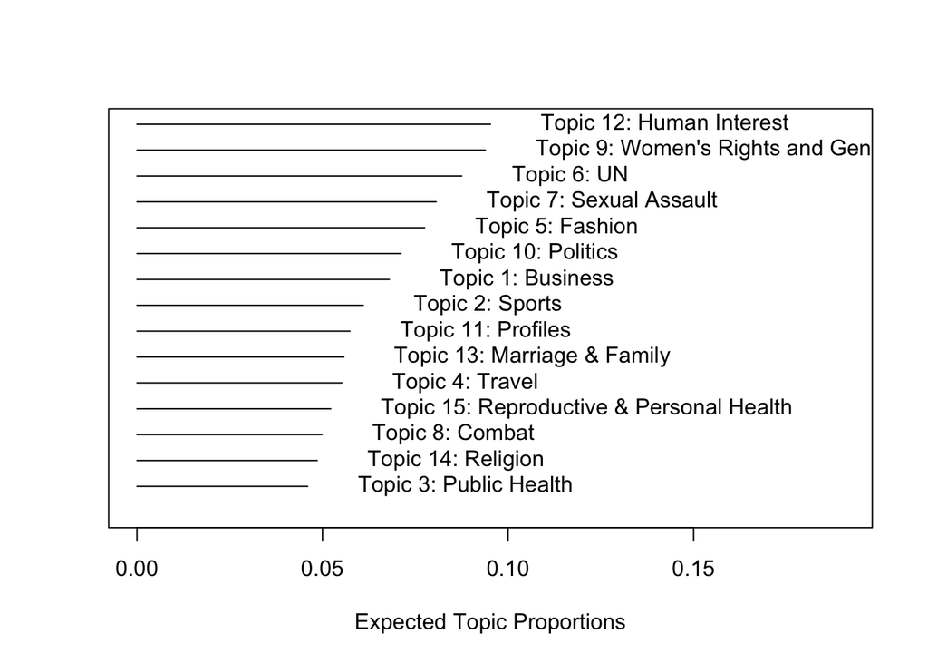

```r
# Corpus Summary
plot.STM(model,type="summary",custom.labels=labels,main="")
```

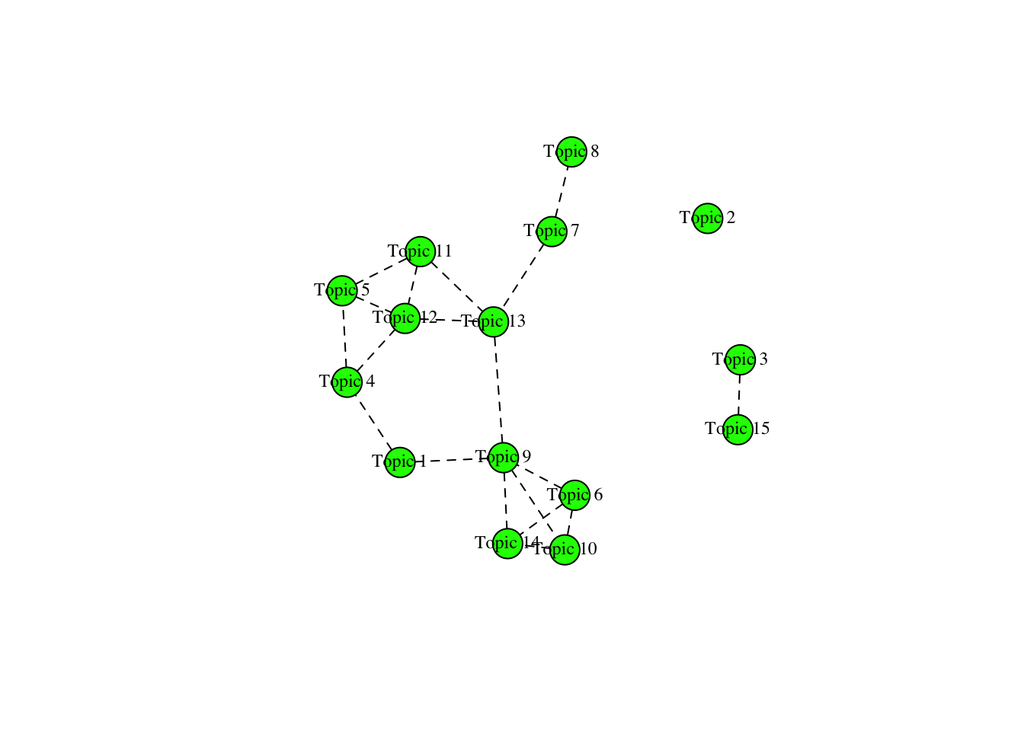

```r
# Topic Correlation
mod.out.corr<-topicCorr(model)
plot.topicCorr(mod.out.corr)
```

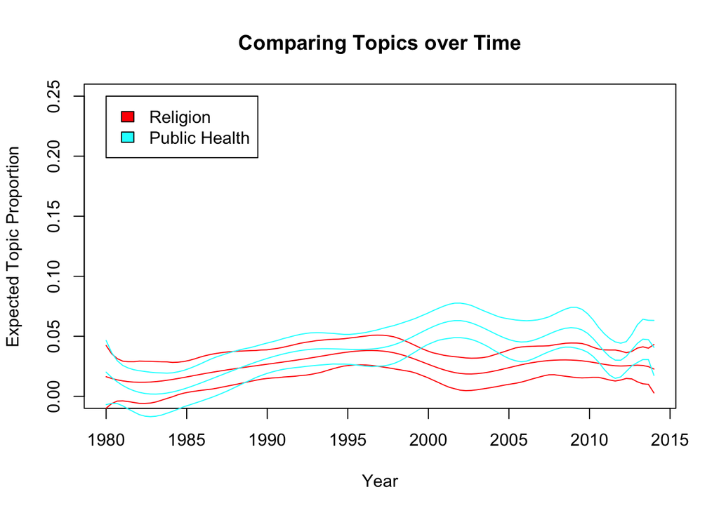

```r
# Estimate Covariate Effects
prep <- estimateEffect(1:15 ~ REGION+s(YEAR),model,meta=meta,uncertainty="Global",documents=docs)

# Topics over time
plot.estimateEffect(prep,covariate="YEAR",method="continuous",topics=c(14, 3),printlegend=TRUE,xlab="Year",xlim=c(1980,2014),main = "Comparing Topics over Time",labeltype="custom",custom.labels=c("Religion", "Public Health"),ylim=c(0,.25),nsims=200)
```

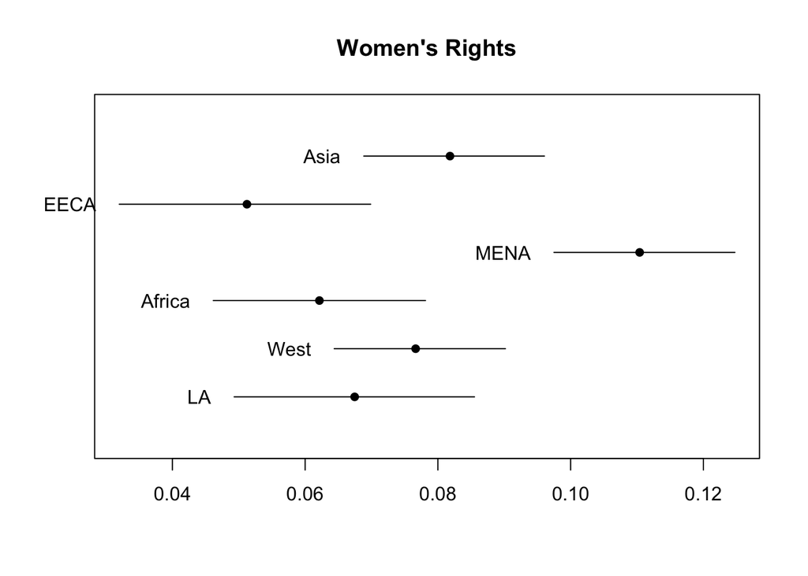

```r
# topics over region
regions = c("Asia","EECA","MENA","Africa","West","LA")
plot.estimateEffect(prep,"REGION",method="pointestimate",topics=9,printlegend=TRUE,labeltype="custom",custom.labels=regions,main="Women's Rights",ci.level=.95,nsims=100)
```